# SLR Review

SDS 291

Feb 10, 2019

# Chapter 0 - What is a Statistical Model?

- Samples, Population
- Statistics, Parameters
- Study designs:
  - Observational
  - Experiments
- Variables:
  - Explanatory
  - Response
- Variable Types / Forms:
  - Quantitative
  - Categorical
    - Binary
      - Indicator
- Modeling partitions data into two components: the model and error

# Chapter 1 - Simple Linear Regression

Remember Porsche Prices? We want to understand the Price of a used Porsche as a function of its Mileage.

- What’s the regression equation?
  - $Y=\beta_0+\beta_1 \cdot Mileage + \epsilon$ where $\epsilon \sim N(0,\sigma_\epsilon)$
- What’s the fitted regression equation?
- Pay attention to hats and errors!
  - When do hats appear?
  - When don’t error terms appear in equations? Why?
- What is the residual? How do you calculate it?
- What is the sum of squared residuals/error (SSE)? Why do we square and then sum the residuals?

# Chapter 1 - Simple Linear Regression

Remember Porsche Prices? We want to understand the Price of a used Porsche as a function of its Mileage.

# 1.1 Interpreting terms

For the fitted equation $\widehat{Price}=71.09-0.5894\cdot Mileage$ where Prices is in $1000s and Mileage is 1000s of miles.

- Interpret the *intercept*
- Interpret the *slope*
- Calculate and interpret the residual for a car with 21,500 Miles that was sold for $69,4000.

# 1.1 Interpret the slope

```
##
## Call:
## lm(formula = Price ~ Mileage, data = PorschePrice)
##
## Residuals:
##      Min       1Q   Median       3Q      Max
## -19.3077  -4.0470  -0.3945   3.8374  12.6758
##
## Coefficients:
##             Estimate Std. Error t value Pr(>|t|)
## (Intercept) 71.09045    2.36986    30.0  < 2e-16 ***
## Mileage     -0.58940    0.05665   -10.4 3.98e-11 ***
## ---
## Signif. codes:  0 '***' 0.001 '**' 0.01 '*' 0.05 '.' 0.1 ' ' 1
##
## Residual standard error: 7.17 on 28 degrees of freedom
## Multiple R-squared:  0.7945, Adjusted R-squared:  0.7872
## F-statistic: 108.3 on 1 and 28 DF,  p-value: 3.982e-11
```

- *just no*: -.5894
- *still not great*: The slope is -.5894
- *getting there, but not just yet*: Every unit difference in Mileage is associated with a -0.58940 lower value of the outcome.
- *Best*: The slope is the coefficient for Mileage (-0.58940): every additional 1000 miles on a used Porsche is associated with, on average, a $589 lower price.

# 1.2-1.3 Stating and Assessing Conditions of the model

- Define each assumption of the linear regression model
  - Linearity
  - Zero Mean
  - Constant Variance / Homoscedasticity
  - Independence
  - Random and Normally Distributed Errors (for inference)
- Regression Standard Error
  - Size of the “typical” error
  - $\hat{sigma_\epsilon}=\sqrt{\frac{\sum(y-\hat{y})^2}{n-2}}=\sqrt{\frac{SSE}{n-2}}$
    - **Note** - just for simple linear regression
- Know how to evaluate each assumption
  - Residual x Fitted Plots
  - Normal Quantile Plot (QQPlot)
  - Histogram

# Chapter 2

# Hypothesis Testing

- Know the null and alternative hypotheses for the different tests we have covered.

# Confidence Interval Interpretation

```
##
## Call:
## lm(formula = Price ~ Mileage, data = PorschePrice)
##
## Residuals:
##      Min       1Q   Median       3Q      Max
## -19.3077  -4.0470  -0.3945   3.8374  12.6758
##
## Coefficients:
##             Estimate Std. Error t value Pr(>|t|)
## (Intercept) 71.09045    2.36986    30.0  < 2e-16 ***
## Mileage     -0.58940    0.05665   -10.4 3.98e-11 ***
## ---
## Signif. codes:  0 '***' 0.001 '**' 0.01 '*' 0.05 '.' 0.1 ' ' 1
##
## Residual standard error: 7.17 on 28 degrees of freedom
## Multiple R-squared:  0.7945, Adjusted R-squared:  0.7872
## F-statistic: 108.3 on 1 and 28 DF,  p-value: 3.982e-11
```

```
##                  2.5 %     97.5 %
## (Intercept) 66.2360186 75.9448869
## Mileage     -0.7054401 -0.4733618
```

**Interpret the Confidence Interval for Mileage**

- *Just no*: The 95% Confidence Interval is -.71,-0.47.
- *Good*: We are 95% confident that the true value for $\beta_1$ is between -0.705 and -0.473.
- *Better*: We are 95% condident that the true association between a Porsche’s mileage and it price is between -0.705 and -0.473.
- *Best*: We are 95% condident that the true association between a Porsche’s mileage and it price is between -0.705 and -0.473. In other words, we are 95% confident that, overall in the population, for every additional 1,000 miles a Porsche has, its price will be $705 to $473 lower.

# p-value interpretation

```
##
## Call:
## lm(formula = Price ~ Mileage, data = PorschePrice)
##
## Residuals:
##      Min       1Q   Median       3Q      Max
## -19.3077  -4.0470  -0.3945   3.8374  12.6758
##
## Coefficients:
##             Estimate Std. Error t value Pr(>|t|)
## (Intercept) 71.09045    2.36986    30.0  < 2e-16 ***
## Mileage     -0.58940    0.05665   -10.4 3.98e-11 ***
## ---
## Signif. codes:  0 '***' 0.001 '**' 0.01 '*' 0.05 '.' 0.1 ' ' 1
##
## Residual standard error: 7.17 on 28 degrees of freedom
## Multiple R-squared:  0.7945, Adjusted R-squared:  0.7872
## F-statistic: 108.3 on 1 and 28 DF,  p-value: 3.982e-11
```

From OpenIntro: > The p-value is the probability of observing data at least as favorable to the alternative hypothesis as our current data set, if the null hypothesis were true. > We say that the data provide statistically significant evidence against the null hypothesis if the p-value is less than some reference value, usually $\alpha$ = 0.05.

**Interpret the p-value for Mileage**

# ANOVA

```
## Analysis of Variance Table
##
## Response: Price
##           Df Sum Sq Mean Sq F value    Pr(>F)
## Mileage    1 5565.7  5565.7  108.25 3.982e-11 ***
## Residuals 28 1439.6    51.4
## ---
## Signif. codes:  0 '***' 0.001 '**' 0.01 '*' 0.05 '.' 0.1 ' ' 1
```

# $R^2$

```
##
## Call:
## lm(formula = Price ~ Mileage, data = PorschePrice)
##
## Residuals:
##      Min       1Q   Median       3Q      Max
## -19.3077  -4.0470  -0.3945   3.8374  12.6758
##
## Coefficients:
##             Estimate Std. Error t value Pr(>|t|)
## (Intercept) 71.09045    2.36986    30.0  < 2e-16 ***
## Mileage     -0.58940    0.05665   -10.4 3.98e-11 ***
## ---
## Signif. codes:  0 '***' 0.001 '**' 0.01 '*' 0.05 '.' 0.1 ' ' 1
##
## Residual standard error: 7.17 on 28 degrees of freedom
## Multiple R-squared:  0.7945, Adjusted R-squared:  0.7872
## F-statistic: 108.3 on 1 and 28 DF,  p-value: 3.982e-11
```

```
## Analysis of Variance Table
##
## Response: Price
##           Df Sum Sq Mean Sq F value    Pr(>F)
## Mileage    1 5565.7  5565.7  108.25 3.982e-11 ***
## Residuals 28 1439.6    51.4
## ---
## Signif. codes:  0 '***' 0.001 '**' 0.01 '*' 0.05 '.' 0.1 ' ' 1
```

# Note of Caution

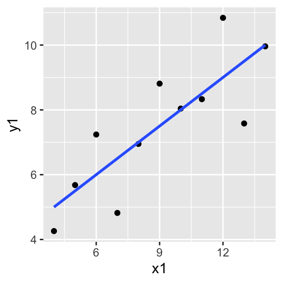

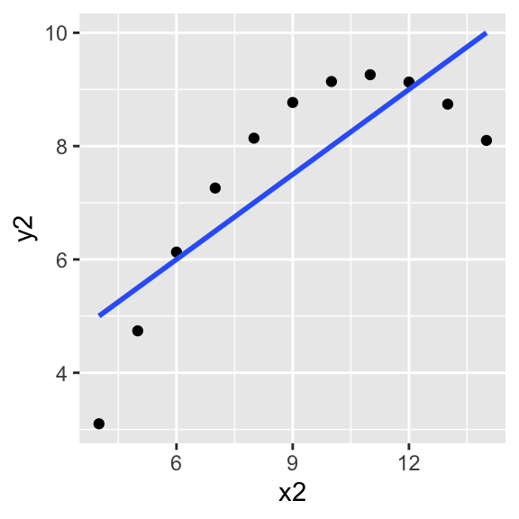

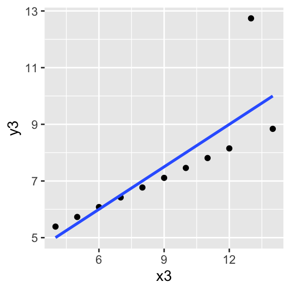

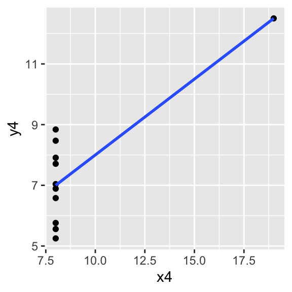